# exploratory correlation

Senna 2024-11-20

```r
spotify_df <- readr::read_csv('https://raw.githubusercontent.com/rfordatascience/tidytuesday/master/data/2020/2020-01-21/spotify_songs.csv')
```

## Data Cleaning

#### feel free to edit as needed, just include a note explaining the changes you made.

What Congyu did here:

1. remove duplicated track_id.  
   There are many songs appear in this dataset more than once, under different genre group and subgenre group, to keep this analysis fair, we remove duplicated songs.
2. remove unique ID columns we are not using.
3. In `track_album_release_date`, many of rows miss month and year, so I create a new column `track_album_release_year` only including release year.
4. factor variables.
5. Adjust dancibility and energy to range 0 - 100 to enlarge the effect on graph.(we can also do this on any other factors we are interested in)
6. clean data based on data dictionary.

```r
spotify_df <-
  spotify_df %>%
  distinct(track_id,.keep_all = T) %>% select(-track_id,-track_album_id,-playlist_id) %>%
  mutate(track_album_release_year = as.numeric(str_sub(track_album_release_date,1,4))) %>%
  select(-track_album_release_date) %>%
  mutate(playlist_name = factor(playlist_name),
         playlist_genre = factor(playlist_genre),
         playlist_subgenre = factor(playlist_subgenre)) %>%
  mutate(danceability = danceability * 100,
         energy = energy * 100) %>%
  mutate(key = factor(case_match(key,0 ~ "C",
                          1 ~ "C#/Db", 2 ~ "D",
                          3 ~ "D#/Eb", 4 ~ "E",
                          5 ~ "F", 6 ~ "F#/Gb",
                          7 ~ "G", 8 ~ "G#/Ab",
                          9 ~ "A", 10 ~ "A#/Bb",
                          11 ~ "B")),
         mode = factor(case_match(mode, 0 ~ "minor",
                          1 ~ "Major")),
         speechiness = factor(case_when(speechiness < 0.33 ~ "non-speech-like music",
                                 speechiness >= 0.33 & speechiness <= 0.66 ~ "mix of speech and music",
                                 speechiness > 0.66 ~ "entirely of spoken words")))
```

```r
spotify_df %>% group_by(playlist_genre) %>%
  summarise(genre_freq = n()) %>% knitr::kable()
```

| playlist_genre | genre_freq |
| --- | --- |
| edm | 4877 |
| latin | 4137 |
| pop | 5132 |
| r&b | 4504 |
| rap | 5401 |
| rock | 4305 |

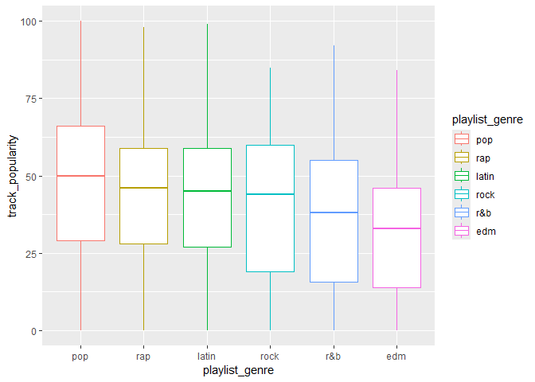

```r
spotify_df %>%
  mutate(playlist_genre = fct_infreq(playlist_genre,track_popularity)) %>%
  ggplot(aes(x = playlist_genre, y = track_popularity, color = playlist_genre)) +
  geom_boxplot()
```

We can see there is a obvious trend between song’s popularity and its genre. Pop songs is the most popular genre and edm is the least.

## Question 1

```r
numeric_var = spotify_df[sapply(spotify_df, is.numeric)]

cor_matr = melt(cor(numeric_var, use = "complete.obs"))
```

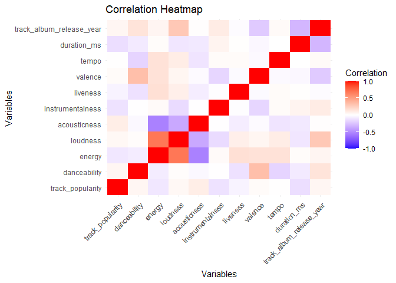

```r
ggplot(cor_matr, aes(Var1, Var2, fill = value)) +
  geom_tile() +
  scale_fill_gradient2(low = "blue", mid = "white", high = "red", midpoint = 0, limit = c(-1, 1)) +
  theme_minimal() +
  theme(axis.text.x = element_text(angle = 45, hjust = 1)) +
  labs(title = "Correlation Heatmap", x = "Variables", y = "Variables", fill = "Correlation")
```

```r
cor_pop = spotify_df |>
  select(where(is.numeric)) |>
  select(-track_popularity) |>
  summarise(across(everything(), ~ cor(.x, spotify_df$track_popularity, use = "complete.obs"))) |>
  pivot_longer(everything(), names_to = "variable", values_to = "correlation") |>
  arrange(desc(correlation))

cor_pop
```

```
## # A tibble: 10 × 2
##    variable                 correlation
##    <chr>                          <dbl>
##  1 acousticness                 0.0917
##  2 danceability                 0.0466
##  3 track_album_release_year     0.0447
##  4 loudness                     0.0373
##  5 valence                      0.0226
##  6 tempo                        0.00445
##  7 liveness                    -0.0528
##  8 energy                      -0.104
##  9 instrumentalness            -0.124
## 10 duration_ms                 -0.140
```

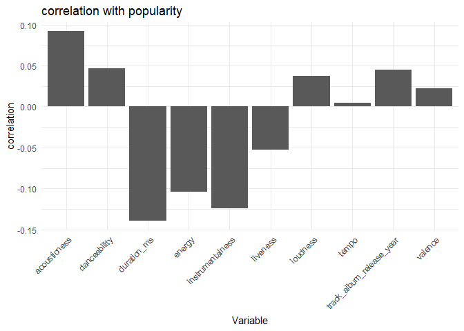

```r
cor_pop|>
  ggplot(aes(x= variable, y = correlation))+
  geom_col() +
  theme_minimal() +
  theme(axis.text.x = element_text(angle = 45, hjust = 1)) +
  labs(title = "correlation with popularity", x = "Variable", y = "correlation")
```

## Question 3

### energy

```r
lm(track_popularity ~ energy, data = spotify_df) %>%
  summary()
```

```
##
## Call:
## lm(formula = track_popularity ~ energy, data = spotify_df)
##
## Residuals:
##     Min      1Q  Median      3Q     Max
## -48.295 -18.181   2.921  18.545  59.977
##
## Coefficients:
##             Estimate Std. Error t value Pr(>|t|)
## (Intercept) 48.67731    0.55092   88.36   <2e-16 ***
## energy      -0.13384    0.00763  -17.54   <2e-16 ***
## ---
## Signif. codes:  0 '***' 0.001 '**' 0.01 '*' 0.05 '.' 0.1 ' ' 1
##
## Residual standard error: 23.58 on 28354 degrees of freedom
## Multiple R-squared:  0.01074,    Adjusted R-squared:  0.0107
## F-statistic: 307.8 on 1 and 28354 DF,  p-value: < 2.2e-16
```

From this simple linear regression, we got a super small p-value, which means we can reject the null hypothesis and conclude that energy is a significant predictor for popularity.

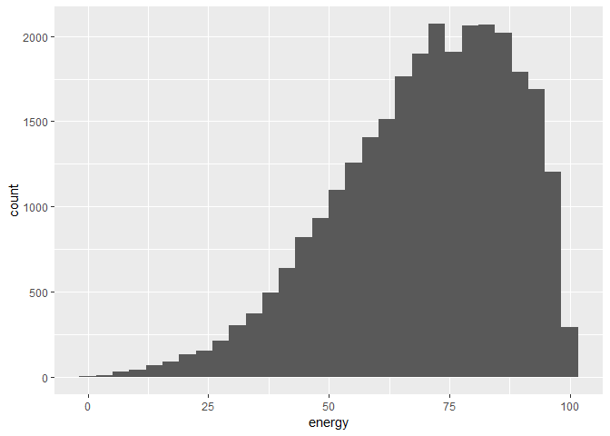

```r
spotify_df %>%
  ggplot(aes(x = energy)) +
  geom_histogram()
```

From this plot we can see, singers prefer to produce and sing energetic (fast, loud, and noisy) music.

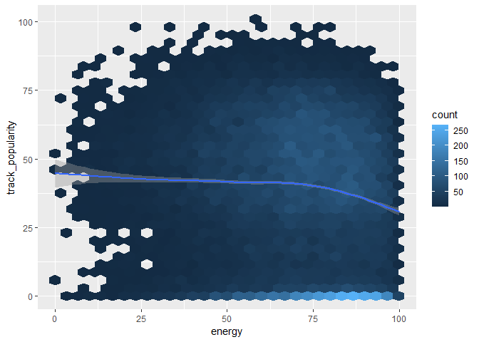

```r
spotify_df %>%
  ggplot(aes(x = energy, y = track_popularity)) +
  geom_hex()+
  geom_smooth()
```

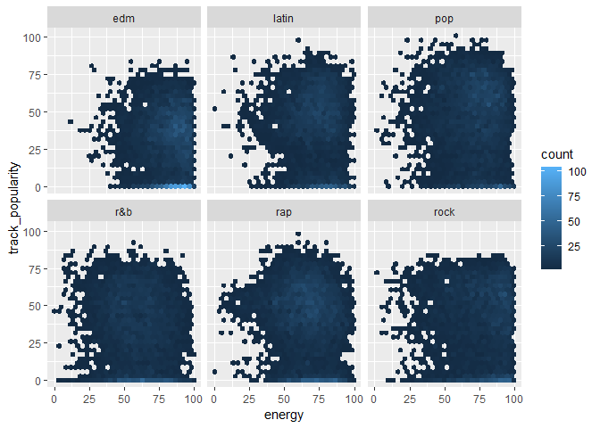

```r
spotify_df %>% group_by(playlist_genre) %>%
  ggplot(aes(x = energy, y = track_popularity)) +
  geom_hex()+
  facet_wrap(~ playlist_genre,nrow = 2)
```

Although, we realize that energy is a significant predictor for popularity and current singers and song producers prefer quick and loud songs. Unfortunalty, we cannot see obvious relationship between songs’ energy and songs’ popularity.

### key

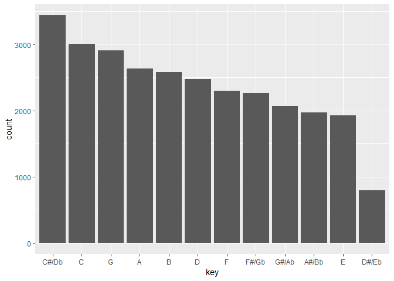

```r
spotify_df %>% mutate(key = fct_infreq(key)) %>%
  ggplot(aes(x = key)) +
  geom_bar()
```

From this plot we can see, the most commonly used key is `C#/Db`. Because `C#/Db` keys are often used in `R&B` and `Pop` genre. Other than that, singers love to use simpler keys without sharp key or flat key.

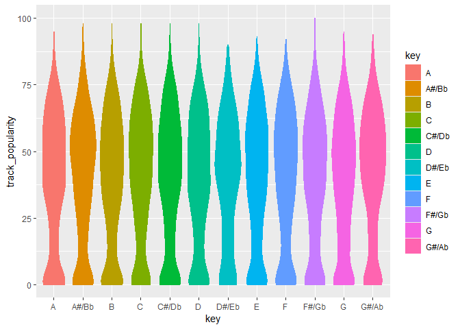

```r
spotify_df %>%
  ggplot(aes(x = key, y = track_popularity,fill = key,color = key)) +
  geom_violin()
```

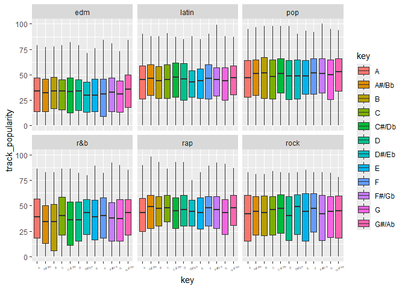

```r
spotify_df %>% group_by(playlist_genre) %>%
  ggplot(aes(x = key, y = track_popularity, fill = key)) +
  geom_boxplot()+
  facet_wrap(~ playlist_genre,nrow = 2)+
  theme(axis.text.x = element_text(size = 4,angle = 30))
```